# Volume 2: The Fourier Transform.

```
Eric Riddoch
Section 2
Nov 29, 2018
```

## Part 1: The Discrete Fourier Transform

```python
from matplotlib import pyplot as plt
import IPython
from scipy.io import wavfile
import numpy as np
from colorama import Fore
from scipy.fftpack import fft, ifft
```

```python
plt.rcParams["figure.dpi"] = 300             # Fix plot quality.
plt.rcParams["figure.figsize"] = (12,3)      # Change plot size / aspect (you may adjust this).
```

```python
class SoundWave(object):
    """A class for working with digital audio signals."""

    SAMPLE_MAX = 32767
    SAMPLE_MIN = -32768

    # constant notes
    notes = {
        'A' : 440,
        'B' : 493.88,
        'C' : 523.25,
        'D' : 587.33,
        'E' : 659.25,
        'F' : 698.46,
        'G' : 783.99,
        'A_high' : 880
    }

    # Problem 1.1
    def __init__(self, rate, samples):
        """Set the SoundWave class attributes.

        Parameters:
            rate (int): The sample rate of the sound.
            samples ((n,) ndarray): NumPy array of samples.
        """
        self.rate = rate
        self.samples = samples
        self.filename = None

    def calculate_hertz(self):
        # return essential information from fft
        n = len(self.samples)
        c_k = abs(fft(self.samples))
        k_indices = np.arange(n)
        frequencies = k_indices * self.rate / n
        return c_k, k_indices, frequencies

    # Problems 1.1 and 1.7
    def plot(self, title="", dft=False):
        """Plot the graph of the sound wave (time versus amplitude)."""
        domain = np.linspace(0, len(self.samples) / self.rate,
                             len(self.samples))

        # case : two subplots
        if dft:
            fig, axes = plt.subplots(1, 2)
            n = len(self.samples)

            # plot soundwave against time
            axes[0].plot(domain, self.samples)
            axes[0].set_ylim(self.SAMPLE_MIN, self.SAMPLE_MAX)
            axes[0].set_ylabel("samples")
            axes[0].set_xlabel("seconds")
            axes[0].set_title("Sound Wave")

            # calculate hertz
            c_k, k_indices, frequencies = self.calculate_hertz()

            # plot magnitude against frequency
            axes[1].plot(frequencies[:n//2], c_k[:n//2])
            axes[1].set_ylabel("amplitude")
            axes[1].set_xlabel("frequency (Hz)")
            axes[1].set_title("Component Frequencies")

            fig.suptitle(f"Fourier Transform - {title}")

        # case : one subplot
        else:
            plt.plot(domain, self.samples)
            plt.ylim(self.SAMPLE_MIN, self.SAMPLE_MAX)
            plt.ylabel("samples")
            plt.xlabel("seconds")
            plt.title(title)

        plt.show()

    # Problem 1.2
    def export(self, filename, force=False):
        """Generate a wav file from the sample rate and samples.
        If the array of samples is not of type np.int16, scale it before exporting.

        Parameters:
            filename (str): The name of the wav file to export the sound to.
        """
        samples = None

        # rescale?
        if self.samples.dtype != np.int16 or force:
            scaled_samples = np.int16( (self.samples * float(self.SAMPLE_MAX))
                                   / max(abs(self.samples)) )
            samples = scaled_samples
        else:
            samples = self.samples

        wavfile.write(filename, self.rate, samples)

    def get_note(self, sound, tol=5):
        """Given a frequency, identify the note it corresponds with."""

        # find the note
        for note in self.notes.keys():
            if abs(sound - self.notes[note]) < tol:
                return note



    # Problem 1.4
    def __add__(self, other):
        """Combine the samples from two SoundWave objects.

        Parameters:
            other (SoundWave): An object containing the samples to add
                to the samples contained in this object.

        Returns:
            (SoundWave): A new SoundWave instance with the combined samples.

        Raises:
            ValueError: if the two sample arrays are not the same length.
        """

        # componentwise add two sounds
        if len(self.samples) != len(other.samples):
            raise ValueError("DUMB!")

        return SoundWave(self.rate, self.samples + other.samples)

    # Problem 1.4
    def __rshift__(self, other):
        """Concatentate the samples from two SoundWave objects.

        Parameters:
            other (SoundWave): An object containing the samples to concatenate
                to the samples contained in this object.

        Raises:
            ValueError: if the two sample rates are not equal.
        """

        # concatenate two sound waves

        if self.rate != other.rate:
            raise ValueError("DUMB!")

        return SoundWave(self.rate, np.hstack([self.samples, other.samples]))

    # Problem 2.1
    def __mul__(self, other):
        """Convolve the samples from two SoundWave objects using circular convolution.

        Parameters:
            other (SoundWave): An object containing the samples to convolve
                with the samples contained in this object.

        Returns:
            (SoundWave): A new SoundWave instance with the convolved samples.

        Raises:
            ValueError: if the two sample rates are not equal.
        """
        raise NotImplementedError("Problem 2.1 Incomplete")

    # Problem 2.2
    def __pow__(self, other):
        """Convolve the samples from two SoundWave objects using linear convolution.

        Parameters:
            other (SoundWave): An object containing the samples to convolve
                with the samples contained in this object.

        Returns:
            (SoundWave): A new SoundWave instance with the convolved samples.

        Raises:
            ValueError: if the two sample rates are not equal.
        """
        raise NotImplementedError("Problem 2.2 Incomplete")

    # Problem 2.4
    def clean(self, low_freq, high_freq):
        """Remove a range of frequencies from the samples using the DFT.

        Parameters:
            low_freq (float): Lower bound of the frequency range to zero out.
            high_freq (float): Higher boound of the frequency range to zero out.
        """
        raise NotImplementedError("Problem 2.4 Incomplete")

    def set_file(self, filename):
        self.filename = filename

    def play(self, filename=None):
        if filename is None:
            return IPython.display.Audio(rate=self.rate, data=self.samples)
        else:
            return IPython.display.Audio(filename)

    @staticmethod
    def play_file(filename):
        return IPython.display.Audio(filename)

    @classmethod
    def with_file(cls, filename):
        rate, samples = wavfile.read(filename)
        obj = cls(rate, samples)
        obj.set_file(filename)
        return obj
```

### Problem 1.1

- Implement `SoundWave.__init__()`.
- Implement `SoundWave.plot()`.
- Use the `scipy.io.wavefile.read()` and the `SoundWave` class to plot `tada.wav`.

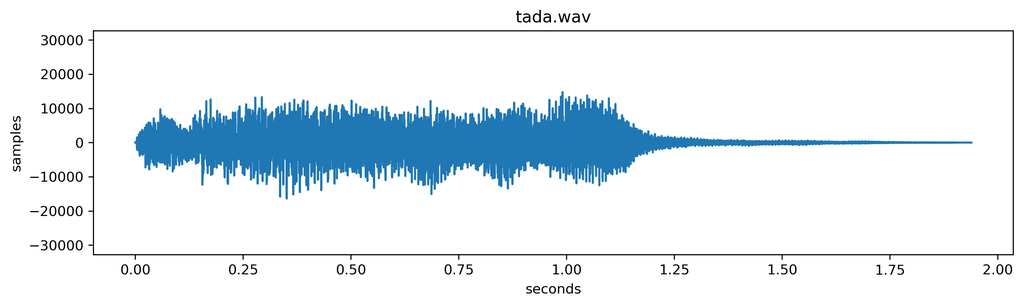

```python
# Plot tada.wav
rate, samples = wavfile.read("tada.wav")
wav = SoundWave(rate, samples)
wav.plot("tada.wav")
```

### Problem 1.2

- Implement `SoundWave.export()`.
- Use the `export()` method to create two new files containing the same sound as `tada.wav`: one without scaling, and one with scaling (use `force=True`).
- Use `IPython.display.Audio()` to embed the original and new versions of `tada.wav` in the notebook.

```python
rate, samples = wavfile.read("tada.wav")
wav = SoundWave(rate, samples)

# create 2 files
wav.export("tada_1.wav")
wav.export("tada_2.wav", force=True)
```

Here: we play the original `tada.wav` file and then the forced and unforced exported versions.

```python
# play file
wav.play_file("tada.wav")
```

[interactive chart not shown]

```python
# play file
wav.play_file("tada_1.wav")
```

[interactive chart not shown]

```python
# play file
wav.play_file("tada_2.wav")
```

[interactive chart not shown]

### Problem 1.3

- Implement `generate_note()`.
- Use `generate_note()` to create an A tone that lasts for two seconds. Embed it in the notebook.

```python
def generate_note(frequency, duration):
    """Generate an instance of the SoundWave class corresponding to
    the desired soundwave. Uses sample rate of 44100 Hz.

    Parameters:
        frequency (float): The frequency of the desired sound.
        duration (float): The length of the desired sound in seconds.

    Returns:
        sound (SoundWave): An instance of the SoundWave class.
    """

    # create a SoundWave with the given frequency
    RATE = 44100
    num_samples = duration * RATE
    domain = np.linspace(0, num_samples / RATE, num_samples)
    samples = np.sin(2*np.pi * domain * frequency)

    return SoundWave(RATE, samples)
```

```python
# 2 second A note
generate_note(SoundWave.notes['A'], 2).play()
```

[interactive chart not shown]

### Problem 1.4

- Implement `SoundWave.__add__()`.
- Generate a three-second A minor chord (A, C, and E) and embed it in the notebook.
- Implement `SoundWave.__rshift__()`.
- Generate the arpeggio A$\,\rightarrow\,$C$\,\rightarrow\,$E, where each tone lasts one second, and embed it in the notebook.

```python
C_Note = generate_note(SoundWave.notes['C'], 3)
E_Note = generate_note(SoundWave.notes['E'], 3)
A_Note = generate_note(SoundWave.notes['A'], 3)
C_Up = generate_note(SoundWave.notes['C'] + 440, 3)
G = 783.99

# Play A, C, and E together, the arpegio is below
(C_Note + E_Note + A_Note).play()
```

[interactive chart not shown]

```python
# Raise Value Error
generate_note(SoundWave.notes['A'], 1) + generate_note(SoundWave.notes['A'], 2)
```

```
---------------------------------------------------------------------------
ValueError                                Traceback (most recent call last)
<ipython-input-12-31b22886e5c1> in <module>()
      1 # Raise Value Error
----> 2 generate_note(SoundWave.notes['A'], 1) + generate_note(SoundWave.notes['A'], 2)

<ipython-input-3-5b9ecc8c48ce> in __add__(self, other)
    123         # componentwise add two sounds
    124         if len(self.samples) != len(other.samples):
--> 125             raise ValueError("DUMB!")
    126
    127         return SoundWave(self.rate, self.samples + other.samples)

ValueError: DUMB!
```

```python
# Mario :D

E = SoundWave.notes['E']
C = SoundWave.notes['C']
G = SoundWave.notes['G']

(
    generate_note(E, .15) >> generate_note(0, .1) >>
    generate_note(E, .15) >> generate_note(0, .2) >>
    generate_note(E, .15) >> generate_note(0, .2) >>
    generate_note(C, .15) >> generate_note(0, .2) >>
    generate_note(E, .15) >> generate_note(0, .2) >>
    generate_note(G, .5) >> generate_note(0, .5)
).play()
```

[interactive chart not shown]

```python
# test note
(generate_note(SoundWave.notes['A'], 1) >> generate_note(SoundWave.notes['B'], 1)).play()
```

[interactive chart not shown]

We generate the 'arpegio' $A \rightarrow C \rightarrow E$ where each note lasts for one second.

```python
# do what the above says
ACE = (generate_note(SoundWave.notes['A'], 1)
       >> generate_note(SoundWave.notes['C'], 1)
       >> generate_note(SoundWave.notes['E'], 1))
ACE.play()
```

[interactive chart not shown]

### Problem 1.5

- Implement `simple_dft()` with the formula for $c_k$ given below.
- Use `np.allclose()` to check that `simple_dft()` and `scipy.fftpack.fft()` give the same result (after scaling).

$$ c_k = \frac{1}{n}\sum_{\ell=0}^{n-1} f_\ell e^{-2 \pi i k \ell\, /\, n} $$

```python
def simple_dft(samples):
    """Compute the DFT of an array of samples.

    Parameters:
        samples ((n,) ndarray): an array of samples.

    Returns:
        ((n,) ndarray): The DFT of the given array.
    """


    # calculate the DFT of any vector
    def DFT(f):
        """
        Compute the discrete Fourier Transform of the 1D array"""

        n = len(f)
        m = np.arange(n).reshape(n,1)
        W = np.exp((-2j * np.pi/float(n)) * m @ m.T)
        return W @ f / float(n)

    return DFT(samples)
```

```python
# calculate DFT(A)
A_note = generate_note(SoundWave.notes['A'], .1)

my_dft = simple_dft(A_note.samples)
print("OUR DFT")
print(my_dft)

print("SCIPY DFT")
scipy_dft = fft(A_note.samples)
scale = len(A_note.samples)
scipy_dft /= scale
print(scipy_dft)

print()
print(f"{Fore.BLUE}The answers are close: {Fore.GREEN}{np.allclose(scipy_dft, my_dft)}{Fore.BLACK}")
```

```
OUR DFT
[-1.58148781e-17+0.00000000e+00j  3.67116142e-09-5.15337949e-06j
  1.47074375e-08-1.03227508e-05j ...  3.31775586e-08+1.55242715e-05j
  1.47074357e-08+1.03227508e-05j  3.67116093e-09+5.15337950e-06j]
SCIPY DFT
[-2.12824215e-17+0.00000000e+00j  3.67116142e-09-5.15337949e-06j
  1.47074375e-08-1.03227508e-05j ...  3.31775588e-08+1.55242715e-05j
  1.47074375e-08+1.03227508e-05j  3.67116142e-09+5.15337949e-06j]

The answers are close: True
```

Clock problem 5 functions:

```python
# time dft of size 8192
n = 8192
sample = np.random.random(n)
%time simple_dft(sample)
%time fft(sample)
```

```
CPU times: user 4.15 s, sys: 896 ms, total: 5.05 s
Wall time: 3.28 s
CPU times: user 1.5 ms, sys: 85 µs, total: 1.58 ms
Wall time: 390 µs
```

```
array([ 4.15637955e+03 +0.j        , -3.83501809e+01+20.30914118j,
        1.66112173e-03 -8.43831743j, ...,  6.56823347e+00 +5.16558068j,
        1.66112173e-03 +8.43831743j, -3.83501809e+01-20.30914118j])
```

### Problem 1.6

- Implement `simple_fft()`.
- Generate an array of $8192$ random samples and take its DFT using `simple_dft()`, `simple_fft()`, and `scipy.fftpack.fft()`. Print the runtimes of each computation.
- Use `np.allclose()` to check that `simple_fft()` and `scipy.fftpack.fft()` give the same result (after scaling).

```python
def simple_fft(samples, threshold=1):
    """Compute the DFT using the FFT algorithm.

    Parameters:
        samples ((n,) ndarray): an array of samples.
        threshold (int): when a subarray of samples has fewer
            elements than this integer, use simple_dft() to
            compute the DFT of that subarray.

    Returns:
        ((n,) ndarray): The DFT of the given array.
    """

    n = len(samples)

    # I'm using <= and not < since the algorithm in the pdf says to do that
    if n <= threshold:
        return simple_dft(samples)
    else:
        samples_even = simple_fft(samples[::2]) # even samples
        samples_odd = simple_fft(samples[1::2]) # odd samples
        w = np.exp((-2j * np.pi / n) * np.arange(n))
        first_sum = samples_even + w[:n//2] * samples_odd
        second_sum = samples_even + w[n//2:] * samples_odd
        return 0.5 * np.concatenate([first_sum, second_sum])
```

```python
# calculate FFT(A)
noise = np.random.random((2**4))

my_fft = simple_fft(noise)
print("OUR FFT")
print(my_fft)

print("SCIPY FFT")
scipy_fft = fft(noise)
scale = len(noise)
scipy_fft /= scale
print(scipy_fft)

print()
print(f"{Fore.BLUE}The answers are close: {Fore.GREEN}{np.allclose(scipy_fft, my_fft)}{Fore.BLACK}")
```

```
OUR FFT
[ 0.45596233+0.00000000e+00j  0.05307231+7.23003436e-02j
 -0.00679851-7.15904049e-02j  0.0623947 +5.93969294e-03j
  0.00288467-1.84428593e-02j  0.06387525+5.90182674e-02j
  0.01500225+8.02630887e-02j  0.03050602-4.15652997e-02j
  0.03319657-2.58869365e-17j  0.03050602+4.15652997e-02j
  0.01500225-8.02630887e-02j  0.06387525-5.90182674e-02j
  0.00288467+1.84428593e-02j  0.0623947 -5.93969294e-03j
 -0.00679851+7.15904049e-02j  0.05307231-7.23003436e-02j]
SCIPY FFT
[ 0.45596233+0.j          0.05307231+0.07230034j -0.00679851-0.0715904j
  0.0623947 +0.00593969j  0.00288467-0.01844286j  0.06387525+0.05901827j
  0.01500225+0.08026309j  0.03050602-0.0415653j   0.03319657+0.j
  0.03050602+0.0415653j   0.01500225-0.08026309j  0.06387525-0.05901827j
  0.00288467+0.01844286j  0.0623947 -0.00593969j -0.00679851+0.0715904j
  0.05307231-0.07230034j]

The answers are close: True
```

Clock problem 6

```python
# time dft of size 8192
n = 8192
sample = np.random.random(n)
%time simple_fft(sample)
%time fft(sample)
```

```
CPU times: user 439 ms, sys: 12.8 ms, total: 452 ms
Wall time: 188 ms
CPU times: user 132 µs, sys: 10 µs, total: 142 µs
Wall time: 137 µs
```

```
array([ 4.10173065e+03 +0.j        , -5.58729616e+00 -1.03147474j,
        4.08041051e+00+14.92963057j, ...,  4.38428594e+00 -1.5297386j ,
        4.08041051e+00-14.92963057j, -5.58729616e+00 +1.03147474j])
```

### Problem 1.7

- Modify `SoundWave.plot()` so that it accepts a boolean. When the boolean is `True`, take the DFT of the stored samples and plot (in a new subplot) the frequencies present on the $x$-axis and the magnituds of those frequences on the $y$-axis. Only the display the first half of the plot, and adjust the $x$-axis so that it correctly shows the frequencies in Hertz.
- Display the plot of the DFT of an A tone.
- Display the plot of the DFT of an A minor chord.

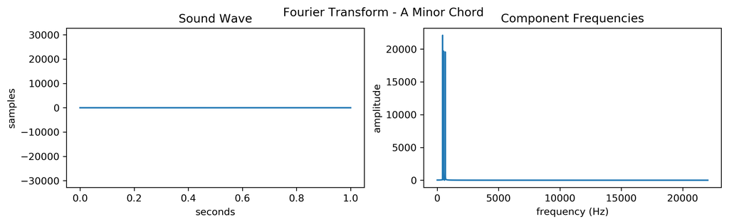

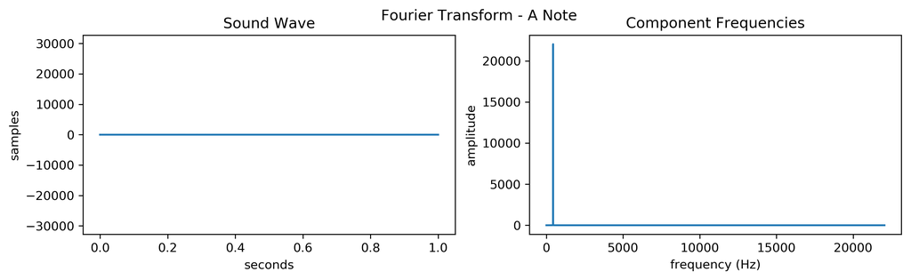

```python
# Plot A minor chord
A_minor = (generate_note(SoundWave.notes['C'], 1) +
                    generate_note(SoundWave.notes['E'], 1) +
                    generate_note(SoundWave.notes['A'], 1) )

A_minor.play()
A_minor.plot("A Minor Chord", dft=True)

# Plot A note
A_note = generate_note(440, 1)
A_note.plot("A Note", dft=True)
```

### Problem 1.8

Use the DFT to determine the individual notes that are present in `mystery_chord.wav`.

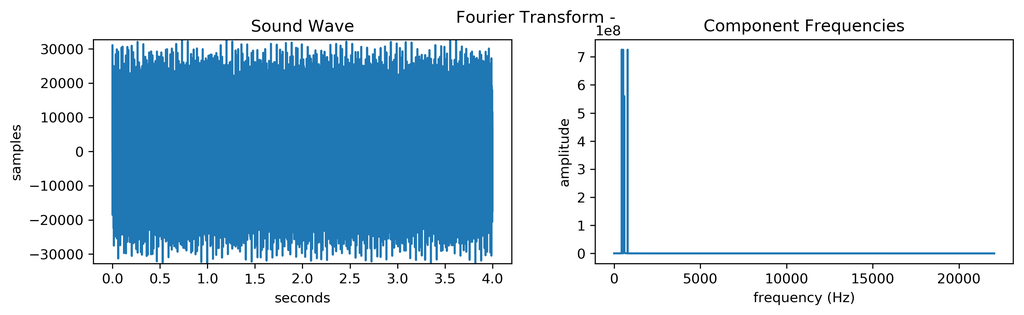

```
The notes are as follows:
440.0
A
784.0
G
523.25
C
587.5
D

My recreation of the chord:
```

[interactive chart not shown]

```python
mystery_chord = SoundWave.with_file("mystery_chord.wav")

mystery_chord.plot(dft=True)

c_k, k_indicies, frequencies = mystery_chord.calculate_hertz()
n = len(c_k)
sort = np.argsort(c_k[:n//2])[::-1]

print(f"{Fore.GREEN}The notes are as follows:{Fore.BLUE}")
for i in range(4):
    print(frequencies[sort[i]])
    print(mystery_chord.get_note(frequencies[sort[i]]))
print(f"{Fore.BLACK}")

print("My recreation of the chord:")
my_chord = (
    generate_note(SoundWave.notes['A'], 4)
    + generate_note(SoundWave.notes['G'], 4)
    + generate_note(SoundWave.notes['C'], 4)
    + generate_note(SoundWave.notes['D'], 4)
)
my_chord.play()
```

The notes are... A, G, C, D

## Part 2: Convolution and Filtering.

### Problem 2.1

- Implement `SoundWave.__mul__()` for circular convolution.
- Generate 2 seconds of white noise at the same sample rate as `tada.wav`.
- Compute the circular convolution of `tada.wav` and the white noise. Embed the result in the notebook.
- Append the circular convolution to itself and embed the result in the notebook.

### Problem 2.2

- Implement `SoundWave.__pow__()` for linear convolution.
- Time the linear convolution of `CGC.wav` and `GCG.wav` using `SoundWave.__pow__()` and `scipy.signal.fftconvolve()`.
- Embed the two original sounds and their convolutions in the notebook. Check that the convolutions with `SoundWave.__pow__()` and `scipy.signal.fftconvolve()` sound the same.

### Problem 2.3

Use `SoundWave.__pow__()` or `scipy.signal.fftconvolve()` to compute the linear convolution of `chopin.wav` and `balloon.wav`. Embed the two original sounds and their convolution in the notebook.

### Problem 2.4

- Implement `SoundWave.clean()`.
- Clean `noisy1.wav` by filtering out frequencies from $1250$-$2600$ Hz. Embed the original and the cleaned versions in the notebook.
- Clean `noisy2.wav`. Embed the original and the cleaned versions in the notebook.

### Problem 2.5

- Clean `vuvuzela.wav` by filtering bad frequencies out of the left and right channels individually.
- Recombine the left and right channels and embed the result in the notebook.

### Problem 2.6

- Clean up `license_plate.png` so that the year printed on the sticker in the bottom right corner of the plate is legible.
- Display the original and cleaned images.

```python
# Fourier Leakage Amplitude for the DFT
domain = np.linspace(0, 2*np.pi, 100)
def f(x, lamda):
    return np.abs( np.sin(np.pi * (x - lamda)) /
          (len(x) * np.sin( (np.pi)*(lamda - x)/len(x) )))

# plot f for several values of lamda given that N = 100
lamdas = [1, 2, 3, 7, 10, 50, 75, 100, 150]
fig, axes = plt.subplots(len(lamdas))
for i, lamda in enumerate(lamdas):
    axes[i].plot(domain, f(domain, lamda))
    axes[i].set_title(f"λ = {lamda}")

plt.show()
```

[output not shown]

```python
np.array(list(enumerate([1,1,1,1,1])))[:,0]
```